# ColtExpress ScoreHeuristic 2021

The results in the tabs below show the MCTS parameters optimised for ColtExpress when using a `ScoreHeuristic` instead of the default one. The opponents (OSLA and MCTS; not RND) also use the `ScoreHeuristic`, so should improve in quality as well.

Conclusions:

- Tuning MCTS (and doubling the budget) gives only a small advance over the baseline MCTS (58% in 2P, 39% in 3P, 30% in 4P). But performance is much better against the RND and OSLA agents (97%+ versus 31%-77% previously)
- In general the ‘signal’ from NTBEA optimisation is much stronger, with fewer flat marginal distributions across parameters.
- MultiNTBEA still gives pretty dreadful results - but does seem to detect that using MAST for rollouts is a poor option (it makes these much more time-consuming)
- The universally important parameters are rolloutLength (as before, it needs to be 30+), selectionPolicy (SIMPLE, not ROBUST), rolloutType (Random >> MAST). maxTreeDepth is not important.
- The opponentTreePolicy is more important (unexpectedly) for OSLA, RND opponents, with Self and MultiTree options dogin well.
- The treePolicy is important against an MCTS opponent, with UCB-tuned doing especially well.

## Score Opponents

### RND

Mean Win rate over all NTBEA runs

| Type | 2P | 3P | 4P |
| --- | --- | --- | --- |
| Win Rate | 99% | 98% | 98% |

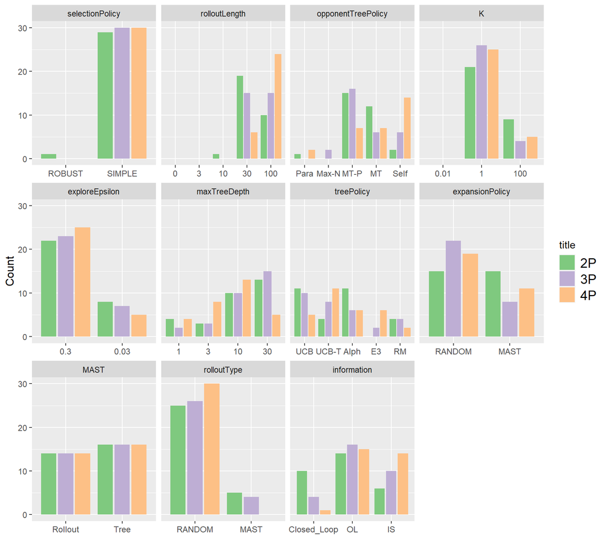

Significant p-Values on Chi-squared test for homogeneity - only extreme values highlighted

| Parameter | 2P | 3P | 4P | All |
| --- | --- | --- | --- | --- |
| selectionPolicy | p < 0.001 | p < 0.001 | p < 0.001 | p < 0.001 |
| rolloutLength | p < 0.001 | p < 0.001 | p < 0.001 | p < 0.001 |
| opponentTreePolicy | p < 0.001 | p < 0.001 | p < 0.001 | p < 0.001 |
| K | p < 0.001 | p < 0.001 | p < 0.001 | p < 0.001 |
| exploreEpsilon |  |  | p < 0.001 | p < 0.001 |
| maxTreeDepth |  |  |  |  |
| treePolicy |  |  |  |  |
| expansionPolicy |  |  |  |  |
| MAST |  |  |  |  |
| rolloutType | p < 0.001 | p < 0.001 | p < 0.001 | p < 0.001 |
| information |  |  |  |  |

### OSLA

Mean Win rate over all NTBEA runs

| Type | 2P | 3P | 4P |
| --- | --- | --- | --- |
| Win Rate | 99% | 98% | 97% |

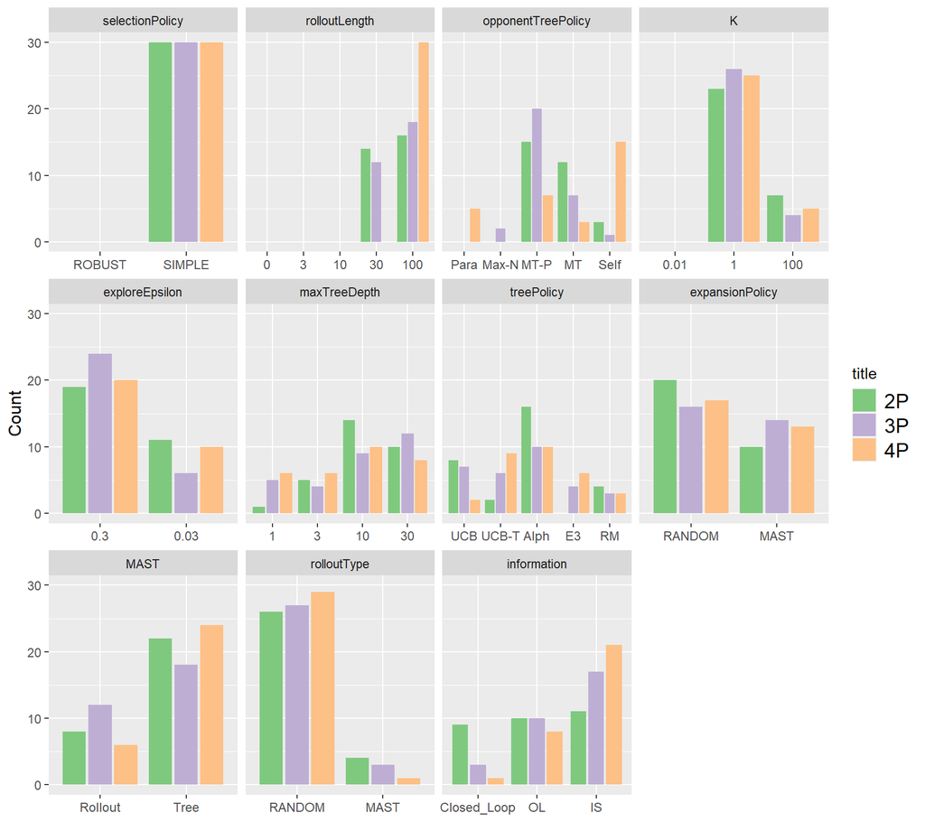

Significant p-Values on Chi-squared test for homogeneity - only extreme values highlighted

| Parameter | 2P | 3P | 4P | All |
| --- | --- | --- | --- | --- |
| selectionPolicy | p < 0.001 | p < 0.001 | p < 0.001 | p < 0.001 |
| rolloutLength | p < 0.001 | p < 0.001 | p < 0.001 | p < 0.001 |
| opponentTreePolicy | p < 0.001 | p < 0.001 | p < 0.001 | p < 0.001 |
| K | p < 0.001 | p < 0.001 | p < 0.001 | p < 0.001 |
| exploreEpsilon |  |  |  |  |
| maxTreeDepth |  |  |  |  |
| treePolicy | p < 0.001 |  |  | p < 0.001 |
| expansionPolicy |  |  |  |  |
| MAST |  |  |  |  |
| rolloutType | p < 0.001 | p < 0.001 | p < 0.001 | p < 0.001 |
| information |  |  | p < 0.001 | p < 0.001 |

### MCTS

Mean Win rate over all NTBEA runs

| Type | 2P | 3P | 4P |
| --- | --- | --- | --- |
| Win Rate | 58% | 39% | 30% |

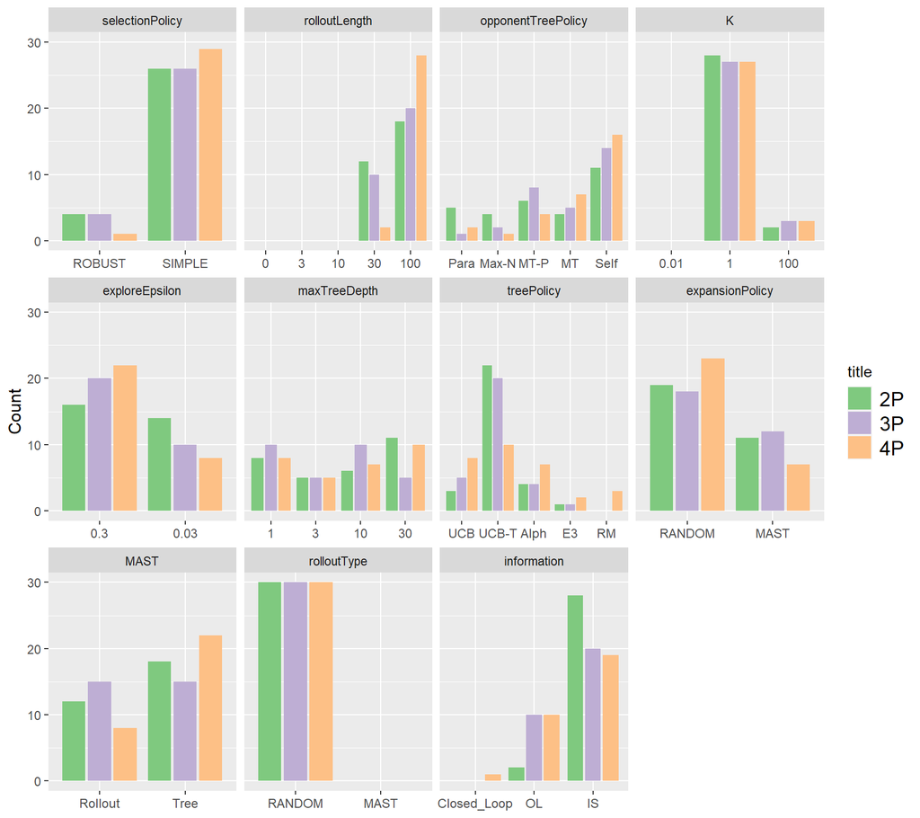

Significant p-Values on Chi-squared test for homogeneity - only extreme values highlighted

| Parameter | 2P | 3P | 4P | All |
| --- | --- | --- | --- | --- |
| selectionPolicy | p < 0.001 | p < 0.001 | p < 0.001 | p < 0.001 |
| rolloutLength | p < 0.001 | p < 0.001 | p < 0.001 | p < 0.001 |
| opponentTreePolicy |  |  | p < 0.001 | p < 0.001 |
| K | p < 0.001 | p < 0.001 | p < 0.001 | p < 0.001 |
| exploreEpsilon |  |  |  |  |
| maxTreeDepth |  |  |  |  |
| treePolicy | p < 0.001 | p < 0.001 |  | p < 0.001 |
| expansionPolicy |  |  |  |  |
| MAST |  |  |  |  |
| rolloutType | p < 0.001 | p < 0.001 | p < 0.001 | p < 0.001 |
| information | p < 0.001 | p < 0.001 | p < 0.001 | p < 0.001 |

### Multi

Mean Win rate over all NTBEA runs

| Type | 2P | 3P | 4P |
| --- | --- | --- | --- |
| Win Rate | 53% | 36% | 27% |

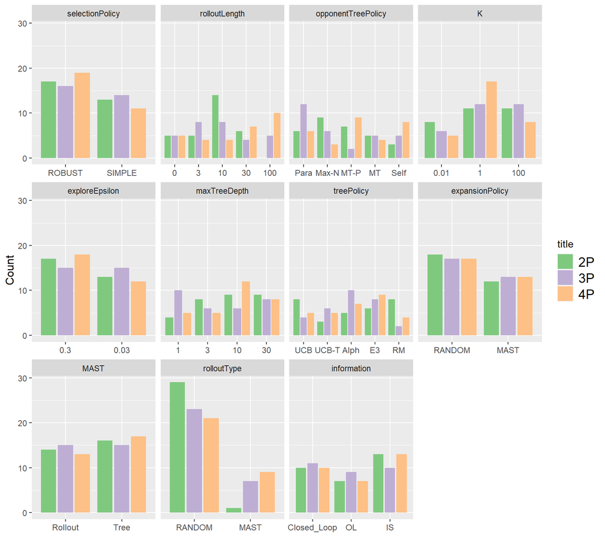

Significant p-Values on Chi-squared test for homogeneity - only extreme values highlighted

| Parameter | 2P | 3P | 4P | All |
| --- | --- | --- | --- | --- |
| selectionPolicy |  |  |  |  |
| rolloutLength |  |  |  |  |
| opponentTreePolicy |  |  |  |  |
| K |  |  |  |  |
| exploreEpsilon |  |  |  |  |
| maxTreeDepth |  |  |  |  |
| treePolicy |  |  |  |  |
| expansionPolicy |  |  |  |  |
| MAST |  |  |  |  |
| rolloutType | p < 0.001 |  |  | p < 0.001 |
| information |  |  |  |  |

### 2P

Mean Win rate over all NTBEA runs

| Type | MCTS | OSLA | RND |
| --- | --- | --- | --- |
| Win Rate | 58% | 99% | 99% |

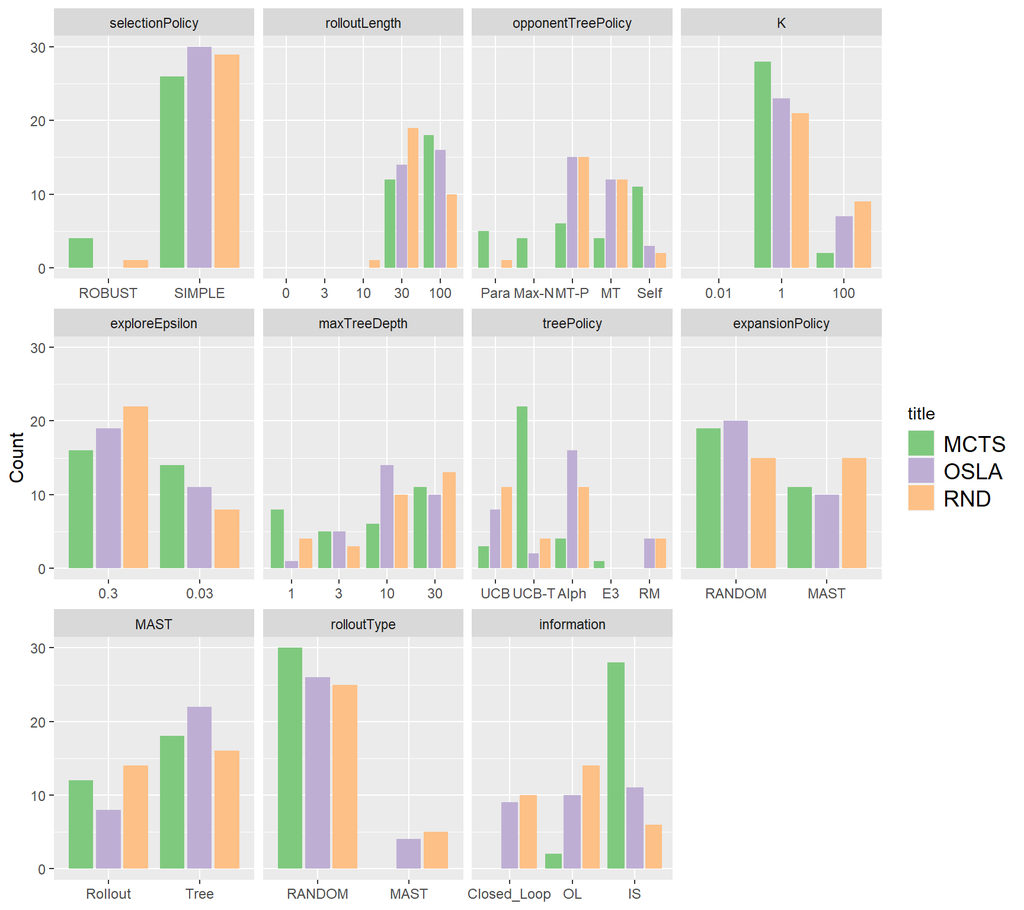

Significant p-Values on Chi-squared test for homogeneity - only extreme values highlighted

| Parameter | MCTS | OSLA | RND | All |
| --- | --- | --- | --- | --- |
| selectionPolicy | p < 0.001 | p < 0.001 | p < 0.001 | p < 0.001 |
| rolloutLength | p < 0.001 | p < 0.001 | p < 0.001 | p < 0.001 |
| opponentTreePolicy |  | p < 0.001 | p < 0.001 | p < 0.001 |
| K | p < 0.001 | p < 0.001 | p < 0.001 | p < 0.001 |
| exploreEpsilon |  |  |  |  |
| maxTreeDepth |  |  |  |  |
| treePolicy | p < 0.001 | p < 0.001 |  | p < 0.001 |
| expansionPolicy |  |  |  |  |
| MAST |  |  |  |  |
| rolloutType | p < 0.001 | p < 0.001 | p < 0.001 | p < 0.001 |
| information | p < 0.001 |  |  | p < 0.001 |

### 3P

Mean Win rate over all NTBEA runs

| Type | MCTS | OSLA | RND |
| --- | --- | --- | --- |
| Win Rate | 39% | 98% | 98% |

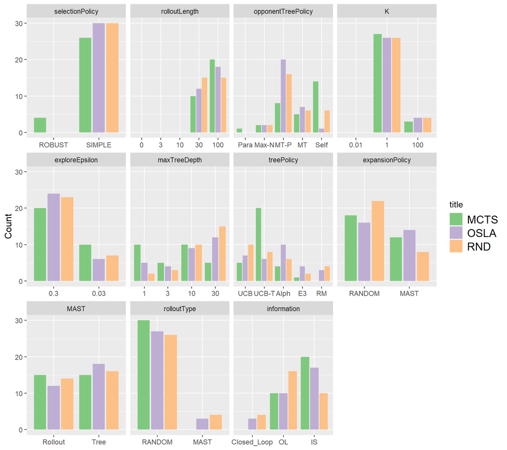

Significant p-Values on Chi-squared test for homogeneity - only extreme values highlighted

| Parameter | MCTS | OSLA | RND | All |
| --- | --- | --- | --- | --- |
| selectionPolicy | p < 0.001 | p < 0.001 | p < 0.001 | p < 0.001 |
| rolloutLength | p < 0.001 | p < 0.001 | p < 0.001 | p < 0.001 |
| opponentTreePolicy |  | p < 0.001 | p < 0.001 | p < 0.001 |
| K | p < 0.001 | p < 0.001 | p < 0.001 | p < 0.001 |
| exploreEpsilon |  |  |  | p < 0.001 |
| maxTreeDepth |  |  |  |  |
| treePolicy | p < 0.001 |  |  | p < 0.001 |
| expansionPolicy |  |  |  |  |
| MAST |  |  |  |  |
| rolloutType | p < 0.001 | p < 0.001 | p < 0.001 | p < 0.001 |
| information | p < 0.001 |  |  | p < 0.001 |

### 4P

Mean Win rate over all NTBEA runs

| Type | MCTS | OSLA | RND |
| --- | --- | --- | --- |
| Win Rate | 30% | 97% | 98% |

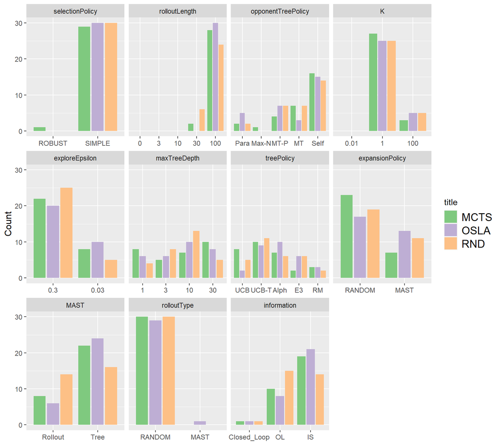

Significant p-Values on Chi-squared test for homogeneity - only extreme values highlighted

| Parameter | MCTS | OSLA | RND | All |
| --- | --- | --- | --- | --- |
| selectionPolicy | p < 0.001 | p < 0.001 | p < 0.001 | p < 0.001 |
| rolloutLength | p < 0.001 | p < 0.001 | p < 0.001 | p < 0.001 |
| opponentTreePolicy | p < 0.001 | p < 0.001 | p < 0.001 | p < 0.001 |
| K | p < 0.001 | p < 0.001 | p < 0.001 | p < 0.001 |
| exploreEpsilon |  |  | p < 0.001 | p < 0.001 |
| maxTreeDepth |  |  |  |  |
| treePolicy |  |  |  |  |
| expansionPolicy |  |  |  |  |
| MAST |  |  |  |  |
| rolloutType | p < 0.001 | p < 0.001 | p < 0.001 | p < 0.001 |
| information | p < 0.001 | p < 0.001 |  | p < 0.001 |

## Overall NTBEA recommendations

Final NTBEA recommendations

| title | WinRate | selectionPolicy | rolloutLength | opponentTreePolicy | K | exploreEpsilon | maxTreeDepth | treePolicy | expansionPolicy | MAST | rolloutType | information |
| --- | --- | --- | --- | --- | --- | --- | --- | --- | --- | --- | --- | --- |
| 2P RND | 99.9 +/- 0.2% | SIMPLE | 30 | MultiTreeParanoid | 1 | 0.30 | 30 | AlphaGo | RANDOM | Rollout | RANDOM | Closed_Loop |
| 2P OSLA | 99.9 +/- 0.2% | SIMPLE | 100 | MultiTreeParanoid | 1 | 0.30 | 30 | UCB | RANDOM | Tree | RANDOM | Open_Loop |
| 2P MCTS | 61.9 +/- 3.2% | SIMPLE | 100 | Paranoid | 1 | 0.30 | 10 | UCB_Tuned | RANDOM | Tree | RANDOM | Information_Set |
| 3P RND | 99.4 +/- 0.5% | SIMPLE | 100 | SelfOnly | 100 | 0.30 | 30 | RegretMatching | RANDOM | Rollout | RANDOM | Open_Loop |
| 3P OSLA | 99.1 +/- 0.6% | SIMPLE | 100 | MultiTreeParanoid | 1 | 0.30 | 30 | UCB_Tuned | RANDOM | Tree | RANDOM | Information_Set |
| 3P MCTS | 44 +/- 3.3% | SIMPLE | 100 | SelfOnly | 1 | 0.03 | 10 | UCB_Tuned | RANDOM | Tree | RANDOM | Information_Set |
| 4P RND | 99.2 +/- 0.6% | SIMPLE | 100 | Paranoid | 100 | 0.30 | 30 | AlphaGo | RANDOM | Tree | RANDOM | Information_Set |
| 4P OSLA | 98.3 +/- 0.9% | SIMPLE | 100 | SelfOnly | 100 | 0.30 | 30 | EXP3 | RANDOM | Tree | RANDOM | Information_Set |
| 4P MCTS | 34.1 +/- 3.2% | ROBUST | 100 | SelfOnly | 1 | 0.03 | 10 | UCB | RANDOM | Tree | RANDOM | Information_Set |